# Twitter analysis

iiro

2018 M07 26

## Included accounts (followers):

**@NordVPN** (15,1K)  
**@FreedomeVPN** (22,1K)  
**@VyprVPN** (9,2K)  
**@hidemyass** (16,3K)  
**@expressvpn** (16,2K)

```r
summary(tweets_all)
```

```
##      text           favoriteCount     replyToSN
##  Length:2765        Min.   :  0.000   Mode:logical
##  Class :character   1st Qu.:  2.000   NA's:2765
##  Mode  :character   Median :  4.000
##                     Mean   :  6.542
##                     3rd Qu.:  8.000
##                     Max.   :353.000
##
##     created                    truncated            id
##  Min.   :2015-06-30 22:27:41   Mode :logical   Length:2765
##  1st Qu.:2017-05-11 02:15:02   FALSE:1069      Class :character
##  Median :2018-01-05 17:42:03   TRUE :1696      Mode  :character
##  Mean   :2017-09-29 17:21:35
##  3rd Qu.:2018-04-17 15:12:01
##  Max.   :2018-07-26 09:33:02
##
##   screenName         retweetCount          weekday         date
##  Length:2765        Min.   :  0.000   Monday   :403   Min.   :2015-06-30
##  Class :character   1st Qu.:  1.000   Tuesday  :431   1st Qu.:2017-05-10
##  Mode  :character   Median :  2.000   Wednesday:494   Median :2018-01-05
##                     Mean   :  4.619   Thursday :489   Mean   :2017-09-29
##                     3rd Qu.:  4.000   Friday   :455   3rd Qu.:2018-04-17
##                     Max.   :298.000   Saturday :264   Max.   :2018-07-26
##                                       Sunday   :229
##       hour        tweet_length
##  Min.   : 0.00   Min.   : 23.0
##  1st Qu.: 9.00   1st Qu.:121.0
##  Median :15.00   Median :134.0
##  Mean   :13.84   Mean   :124.8
##  3rd Qu.:19.00   3rd Qu.:139.0
##  Max.   :23.00   Max.   :148.0
##
```

### Retweets vs favorites

Expectedly there seems to be strong positive correlation between favorites(likes) and retweets, we will be using retweets as success metric from now on.

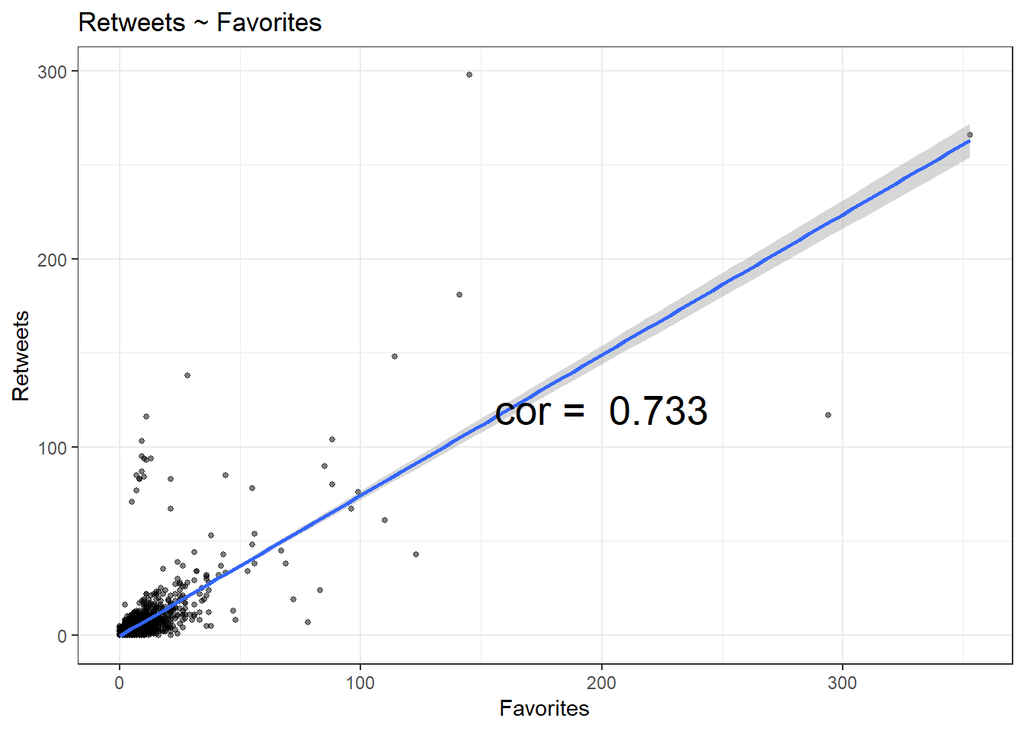

### Tweet lengths

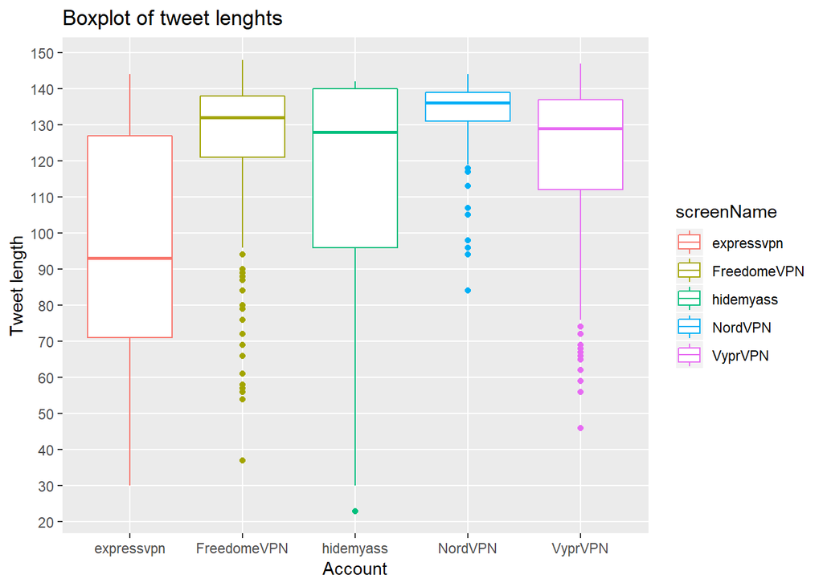

However, there doesn’t seem to be correlation between tweet length and retweet count:

```r
cor(tweets_all$retweetCount, tweets_all$tweet_length)
```

```
## [1] 0.03206332
```

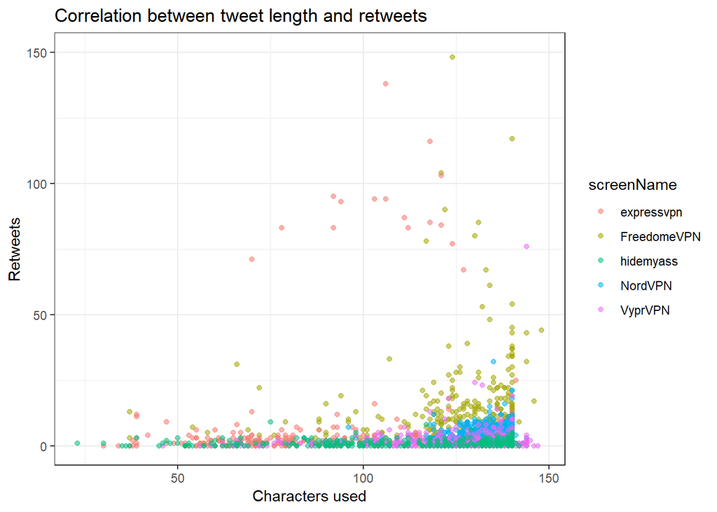

### When do VPNs tweet?

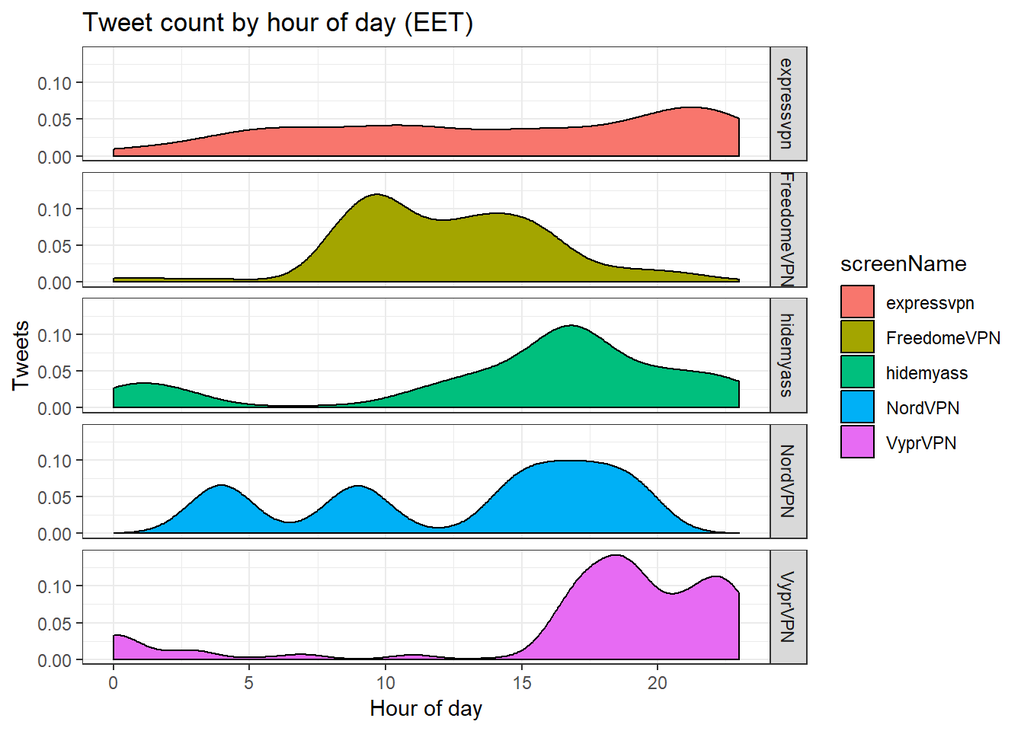

@NordVPN tweets on very steady pace over the week, while others tweet less during weekends.

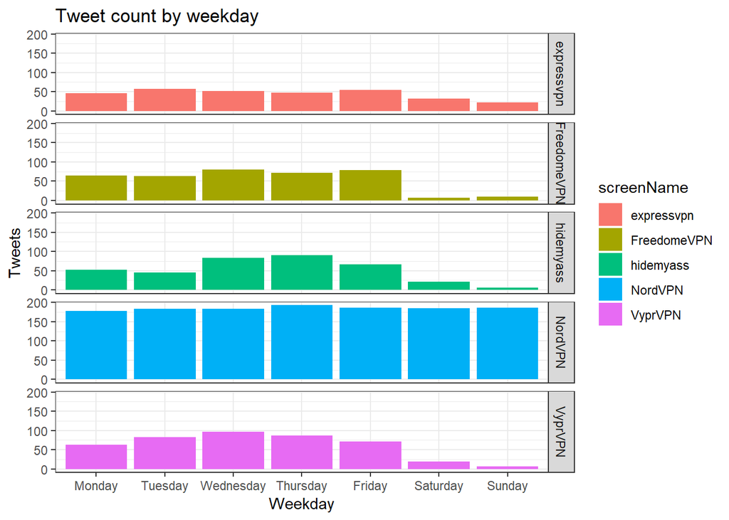

Tweeting during weekend has slightly worse performance retweet -wise during weekends as well. This might be skewed because of only one company tweeting though.

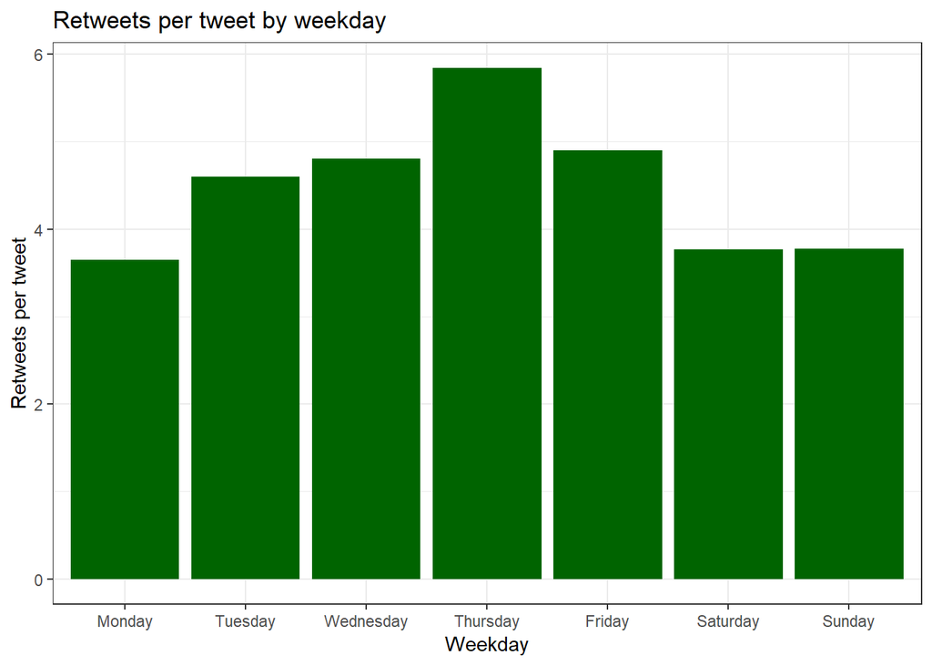

### Tweets trended over time

@NordVPN has had impressive pace since the creation of their Twitter handle, although retweet amounts are low.

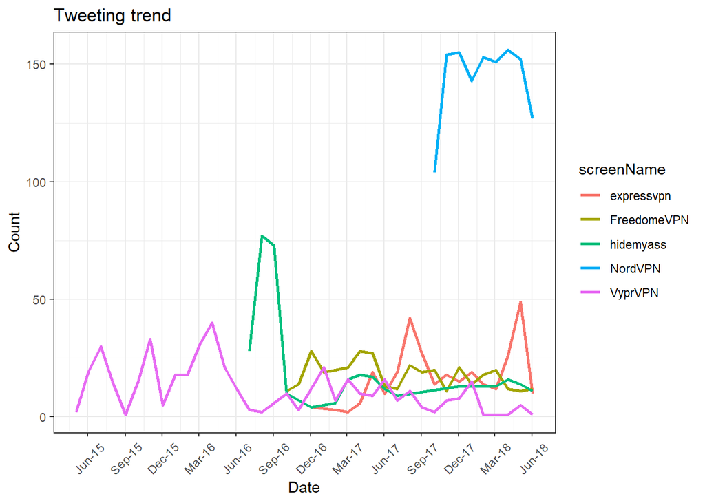

```
## # A tibble: 5 x 4
##   screenName  Tweets retweetsCount `Retweets per Tweet`
##   <chr>        <int>         <dbl>                <dbl>
## 1 FreedomeVPN    373          4963                 13.3
## 2 expressvpn     309          2306                  7.5
## 3 NordVPN       1295          3963                  3.1
## 4 VyprVPN        425          1193                  2.8
## 5 hidemyass      363           347                  1
```

### Top tweets by account

Suprisingly, if the data is correct, @hidemyass has very low retweet counts. Possibly just uninteresting advertising?

| text | screenName | retweetCount | id | tweetURL |
| --- | --- | --- | --- | --- |
| Social media is blocked in #Uganda. Get VyprVPN to access an OPEN Internet: https://t.co/x2F1wnVBgc #ugandadecides https://t.co/0VuIduZBZu | VyprVPN | 298 | 700365162482511872 | https://twitter.com/statuses/700365162482511872 |
| Have you ever downloaded a copy of all the data that #Google has on you? Warning: it’s GIGABYTES and it includes EV… https://t.co/Xl1fpMzzDk | FreedomeVPN | 266 | 978968711297208320 | https://twitter.com/statuses/978968711297208320 |
| VPNs removed from China App Store. Dismayed Apple sided w/ censorship, but we’re committed to keeping you connected: https://t.co/wvVk6IIsD3 | expressvpn | 181 | 891213454996000768 | https://twitter.com/statuses/891213454996000768 |
| Everything you need to know about using Tor Browser: https://t.co/bqubk1ErQJ #Tor #privacy #CyberSecurity #VPN… https://t.co/XigEGEZixQ | NordVPN | 32 | 949906708171821056 | https://twitter.com/statuses/949906708171821056 |
| #WriteAPoemAboutTheresaMay #IPBill #SnoopersCharter https://t.co/qT5v4nwJ9T | hidemyass | 9 | 781776150070722561 | https://twitter.com/statuses/781776150070722561 |